# Data Science for AOG

## What is Data Science

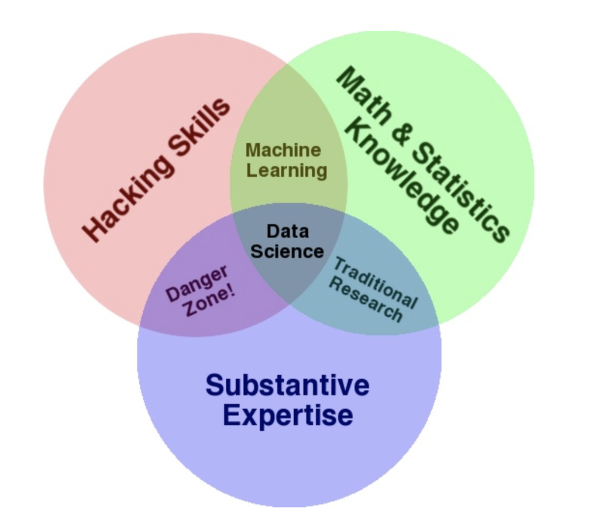

Drew Conway’s Venn Diagram of Data Science

## Fundamental Questions

- What defines success in your business?
- How is this measured?
- What can serve as a proxy?
- Increase Funding -> Engagements from Website -> Clicks on Donate Button

## Fundamental Questions

- What decisions are you making?
- What data have you collected to support that decision making process?
- Until these questions are answered, data science can do little to help

## AB Testing

- Will changing my website layout impact the number of donations?
- Hypothesis: Placing button in middle will increase number of donations

[figure not shown]

## Data

```r
sample.data<-read.csv("click_data.csv")
sample.data<-sample.data %>% mutate(visit_date=mdy(visit_date))
summarized.data<-sample.data %>% group_by(month(visit_date))%>%
  summarise(avg=mean(clicked_adopt_today))
summarized.data
```

```
## # A tibble: 12 x 2
##    `month(visit_date)`   avg
##                  <dbl> <dbl>
##  1                   1 0.197
##  2                   2 0.189
##  3                   3 0.145
##  4                   4 0.15
##  5                   5 0.258
##  6                   6 0.333
##  7                   7 0.348
##  8                   8 0.542
##  9                   9 0.293
## 10                  10 0.161
## 11                  11 0.233
## 12                  12 0.465
```

## Randomizing Experiment

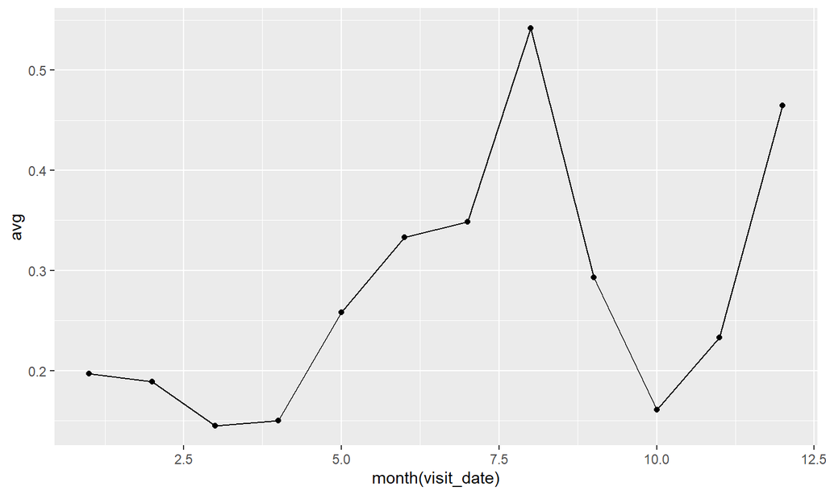

```r
summarized.data %>% ggplot(aes(x=`month(visit_date)`,y=avg))+
  geom_point()+geom_line()
```

## General Technique

- Randomly assign visitors to one of `n` web pages
- Collect number of “successes”
- After designated time period determine if meaningful difference exists

```r
result<-prop.test(x=c(50,30),n=c(200,200),correct = FALSE)
result$p.value
```

```
## [1] 0.01241933
```

## What do these mean?

```r
result$conf.int
```

```
## [1] 0.02221634 0.17778366
## attr(,"conf.level")
## [1] 0.95
```

## Confidence Interval Analysis

```r
result$conf.int
```

```
## [1] 0.02221634 0.17778366
## attr(,"conf.level")
## [1] 0.95
```

- Out of 200 people, we would expect 4-35 more to engage with new webpage
- If each engagement is expected to bring in 1 doller (on average) and new webpage costs an additional 50 dollars a month to maintain, may not be worth it

## Warnings

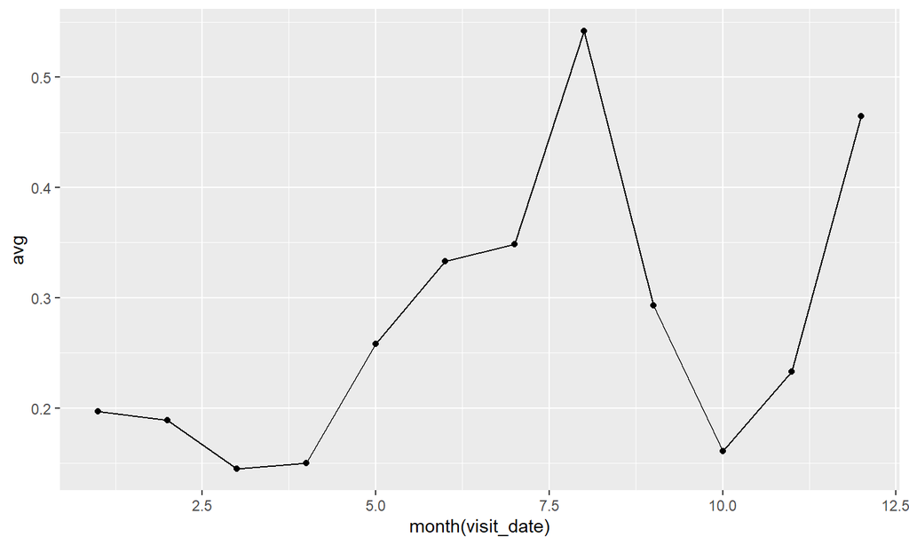

```r
summarized.data %>% ggplot(aes(x=`month(visit_date)`,y=avg))+
  geom_point()+geom_line()
```

- Let’s say trial is done in Month 9 - Does this necessarily mean our results are valid for December?

## What are people saying about you?

- Assumes metric we are interested in is positive tweets that mention WPAOG
- Hypothesis: If I do X, then people will tweet more positively about WPAOG

```r
added = read_csv("AOGTweets.csv")

textcleaned = added %>%
  unnest_tokens(word, text)

cleanedarticle = anti_join(textcleaned,stop_words, by = "word") %>%
  select(line,word,screenname,time,followerscount,favoritescount, searchterm)
```

- Seperated tweets into individual words

## What are people saying about you?

```
## # A tibble: 10 x 2
##    dayofweek  AverageDailySentiment
##    <date>                     <dbl>
##  1 2019-11-06                0.221
##  2 2019-11-07                0.0952
##  3 2019-11-08                0.177
##  4 2019-11-09                0.218
##  5 2019-11-10                0.210
##  6 2019-11-11                0.143
##  7 2019-11-12                0.0115
##  8 2019-11-13                0.198
##  9 2019-11-14                0.192
## 10 2019-11-15                0.108
```

## Most Influential Tweeters

| screenname | text | followerscount | favoritescount | polaritysent | influencescore |
| --- | --- | --- | --- | --- | --- |
| WPAOG | Today we salute all veterans. Thank you to all the brave men and women and members of the #LongGrayLine who served and continue to serve our great nation. #DutyHonorCountry https://t.co/0nNNDVzVyT | 15353 | 95 | 0.1793366 | 17.036979 |
| WPAOG | #OTD 12 November-Today is the birthday of Rebecca E. Marier McGuigan (1995), the first woman to be rated the top all-around West Point graduate–in academic, military training &amp; physical trainingsi… | 15353 | 164 | 0.2392355 | 39.234618 |
| WPAOG | This weekend, WPAOG proudly welcomes the Class of 1994 back to West Point for their 25th reunion! We expect more than 380 graduates, family members and guests to return to USMA for the festivities! #W… | 15353 | 32 | 0.2930217 | 9.376695 |
| WPAOG | Today we salute all veterans. Thank you to all the brave men and women and members of the #LongGrayLine who served and continue to serve our great nation. #DutyHonorCountry https://t.co/0nNNDVzVyT | 15353 | 95 | 0.1793366 | 17.036979 |
| WPAOG | #OTD 12 November-Today is the birthday of Rebecca E. Marier McGuigan (1995), the first woman to be rated the top all-around West Point graduate–in academic, military training &amp; physical trainingsi… | 15353 | 164 | 0.2392355 | 39.234618 |
| WPAOG | This weekend, WPAOG proudly welcomes the Class of 1994 back to West Point for their 25th reunion! We expect more than 380 graduates, family members and guests to return to USMA for the festivities! #W… | 15353 | 32 | 0.2930217 | 9.376695 |

## Most Negatively Influential Tweeters

| screenname | text | followerscount | favoritescount | polaritysent | influencescore |
| --- | --- | --- | --- | --- | --- |
| WPAOG | #OTD 11 Nov 1918, Armistice Day (now Veterans Day in the U.S.) ended World War I, which at the time was The War to End All Wars. Thirty-two West Point graduates were killed in the fighting. #WPAOG150 … | 15353 | 6 | -0.2836056 | -1.7016336 |
| sailingtobyzant | Congratulations to West Point grads in gov. service, except William B Taylor, Jr., Ambassador to Ukraine, who is dishonorably engaged in dishonoring his Commander, President Trump, with triple hearsay… | 2823 | 1 | -0.1092247 | -0.1092247 |
| AEVanSaun | Spent the morning sharing a few stories about my old roommate Dennis, and then going on a run. Can’t believe it’s been 14 years. #StrongGrayLine @WestPoint_USMA @WPAOG https://t.co/jUO3ltYEwf | 634 | 23 | -0.0057540 | -0.1323428 |
| WPAOG | #OTD 11 Nov 1918, Armistice Day (now Veterans Day in the U.S.) ended World War I, which at the time was The War to End All Wars. Thirty-two West Point graduates were killed in the fighting. #WPAOG150 … | 15353 | 6 | -0.2836056 | -1.7016336 |
| sailingtobyzant | Congratulations to West Point grads in gov. service, except William B Taylor, Jr., Ambassador to Ukraine, who is dishonorably engaged in dishonoring his Commander, President Trump, with triple hearsay… | 2823 | 1 | -0.1092247 | -0.1092247 |
| AEVanSaun | Spent the morning sharing a few stories about my old roommate Dennis, and then going on a run. Can’t believe it’s been 14 years. #StrongGrayLine @WestPoint_USMA @WPAOG https://t.co/jUO3ltYEwf | 634 | 23 | -0.0057540 | -0.1323428 |

## Questions need a baseline

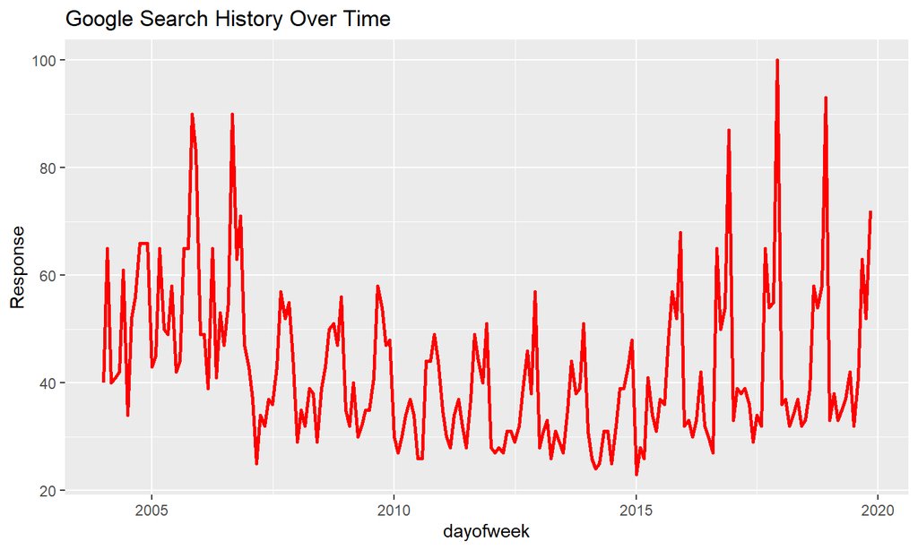

## What does normal look like?

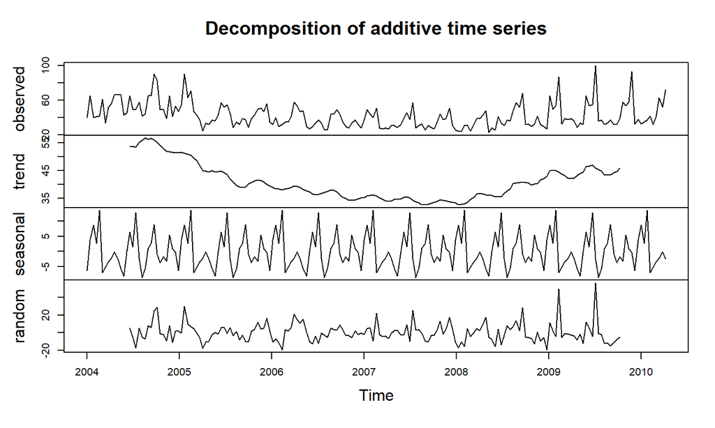

```r
gah<-decompose(ts(trends$Response,freq=364/12,
                  start=decimal_date(ymd("2004-01-01"))))
plot(gah)
```

- Where are we most abnormal

```
## # A tibble: 1 x 2
##   Response dayofweek
##      <dbl> <date>
## 1      100 2017-12-01
```

[figure not shown]

```r
trends %>% mutate(err=gah$random)%>% filter(err > 30)
```

```
## # A tibble: 3 x 3
##   Response dayofweek    err
##      <dbl> <date>     <dbl>
## 1       90 2006-09-01  30.1
## 2       87 2016-12-01  49.5
## 3      100 2017-12-01  56.6
```